# Расчёт полей тороидально намагниченного цилиндра с намагниченностью обратной радиусу в опыте Дейны (опыт Николаева номер 31)

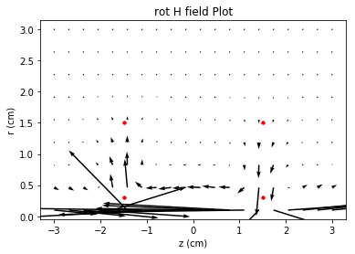

```python
fig,ax=plt.subplots(1,1)
matplotlib_draw_cylinder(ax, z0 = 0)
ax.quiver(za_grid,ra_grid,u,v)
ax.set_title('rot H field Plot')
ax.set_xlabel('z (cm)')
ax.set_ylabel('r (cm)')
plt.show()
```

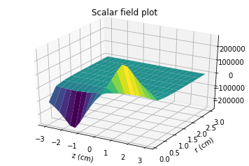

```python
from mpl_toolkits import mplot3d
import numpy as np
import matplotlib.pyplot as plt
fig = plt.figure()

ax = plt.axes(projection='3d')
ax.set_xlabel('z (cm)')
ax.set_ylabel('r (cm)')
ax.plot_surface(za_grid,ra_grid, s, cmap='viridis', edgecolor='none')
ax.set_title('Scalar field plot')
plt.show()
```

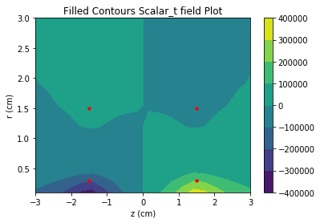

```python
fig,ax=plt.subplots(1,1)
matplotlib_draw_cylinder(ax, z0 = 0)
cp = ax.contourf(za_grid,ra_grid, s_t)
fig.colorbar(cp) # Add a colorbar to a plot
ax.set_title('Filled Contours Scalar_t field Plot')
ax.set_xlabel('z (cm)')
ax.set_ylabel('r (cm)')
plt.show()
```

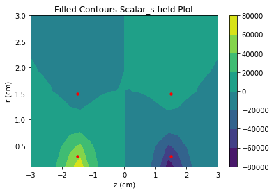

```python
fig,ax=plt.subplots(1,1)
matplotlib_draw_cylinder(ax, z0 = 0)
cp = ax.contourf(za_grid,ra_grid, s_s)
fig.colorbar(cp) # Add a colorbar to a plot
ax.set_title('Filled Contours Scalar_s field Plot')
ax.set_xlabel('z (cm)')
ax.set_ylabel('r (cm)')
plt.show()
```

```python
u_ex = u
v_ex = v
s_ex = s
h_ex = h

for iz in np.arange(0, len(za_linspace), 1):
    for ir in np.arange(0, len(ra_linspace), 1):
        Za = za_list[iz]
        Ra = ra_list[ir]
        if Za >= Zj1 and Za <= Zj2 and Ra >= Rj1 and Ra <= Rj2:
            u_ex[ir][iz] = np.nan
            v_ex[ir][iz] = np.nan
            s_ex[ir][iz] = np.nan
            h_ex[ir][iz] = np.nan
```

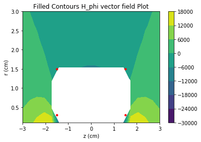

```python
fig,ax=plt.subplots(1,1)
matplotlib_draw_cylinder(ax, z0 = 0)
cp = ax.contourf(za_grid,ra_grid, h_ex)
fig.colorbar(cp) # Add a colorbar to a plot
ax.set_title('Filled Contours H_phi vector field Plot')
ax.set_xlabel('z (cm)')
ax.set_ylabel('r (cm)')
plt.show()
```

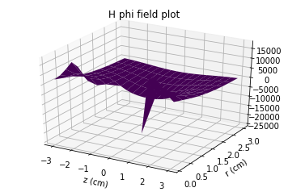

```python
from mpl_toolkits import mplot3d
import numpy as np
import matplotlib.pyplot as plt
fig = plt.figure()

ax = plt.axes(projection='3d')
ax.set_xlabel('z (cm)')
ax.set_ylabel('r (cm)')
ax.plot_surface(za_grid,ra_grid, h_ex, cmap='viridis', edgecolor='none')
ax.set_title('H phi field plot')
plt.show()
```

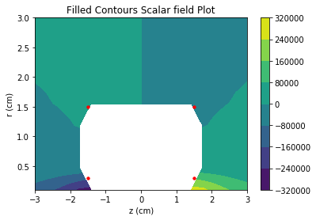

```python
fig,ax=plt.subplots(1,1)
matplotlib_draw_cylinder(ax, z0 = 0)
cp = ax.contourf(za_grid,ra_grid, s_ex)
fig.colorbar(cp) # Add a colorbar to a plot
ax.set_title('Filled Contours Scalar field Plot')
ax.set_xlabel('z (cm)')
ax.set_ylabel('r (cm)')
plt.show()
```

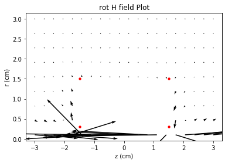

```python
fig,ax=plt.subplots(1,1)
matplotlib_draw_cylinder(ax, z0 = 0)
ax.quiver(za_grid,ra_grid,u_ex,v_ex)
ax.set_title('rot H field Plot')
ax.set_xlabel('z (cm)')
ax.set_ylabel('r (cm)')
plt.show()
```

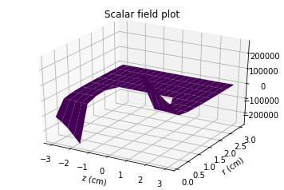

```python
from mpl_toolkits import mplot3d
import numpy as np
import matplotlib.pyplot as plt
fig = plt.figure()

ax = plt.axes(projection='3d')
ax.set_xlabel('z (cm)')
ax.set_ylabel('r (cm)')
ax.plot_surface(za_grid,ra_grid, s_ex, cmap='viridis', edgecolor='none')
ax.set_title('Scalar field plot')
plt.show()
```

```python
u_norm = u
v_norm = v

for iz in np.arange(0, len(za_linspace), 1):
    for ir in np.arange(0, len(ra_linspace), 1):
        n = sqrt(u[ir][iz]^2 + v[ir][iz]^2)
        u_norm[ir][iz] = u[ir][iz] / n
        v_norm[ir][iz] = v[ir][iz] / n
```

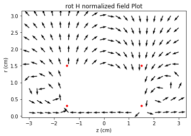

```python
fig,ax=plt.subplots(1,1)
matplotlib_draw_cylinder(ax, z0 = 0)
ax.quiver(za_grid,ra_grid,u_norm,v_norm)
ax.set_title('rot H normalized field Plot')
ax.set_xlabel('z (cm)')
ax.set_ylabel('r (cm)')
plt.show()
```

# Парадокс тороидально намагниченного цилиндра

Удивительным для меня образом я получил отличную от нуля дивергенцию векторного потенциала, хотя, например, в курсе электродинамики Тамма доказывается, что для замкнутых постоянных токов таковая должна быть равна нулю.

Доказательство Тамма равенства нулю дивергенции векторного потенциала для замкнутых систем постоянного тока (И.Е.Тамм, Основы теории электричества, 1957, $\$46$ п.5)

Исходя из уравнения

$$\vec{A} = \frac{1}{c}\,\int\frac{\vec{j}}{R}dV$$

которое в свою очередь получено из уравнения

$$\vec{H} = \frac{1}{c}\,\int\frac{\left[\vec{j}\vec{R}\right]}{R}dV$$

следует

$$div\,\vec{A} = \frac{1}{c}\,div_{a}\,\int\frac{\vec{j}dV}{R}$$

где индекс $a$ у знака дивергенции означает, что пространственное дифференцирование производится по координатам точки наблюдения. Порядок интегрирования по объёму токов и дифференцирования по точке наблюдения может быть заменён на обратный. Стало быть,

$$div\,\vec{A} = \frac{1}{c}\,\int\,div_{a}\left(\frac{\vec{j}}{R}\right)dV$$

Применяя уравнение векторного анализа $div\left(\phi\,\vec{a} \right) = \phi\,div\,\vec{a} + \vec{a}\, grad\,\phi$ можем написать:

$$div_{a}\left(\frac{\vec{j}}{R}\right) = \frac{1}{R}\,div_{a}\,\vec{j} + \vec{j}\,grad_{a}\, \left(\frac{1}{R}\right) = \vec{j}\,grad_{a}\, \left(\frac{1}{R}\right)$$

Поскольку значение $\vec{j}$ от координат точки наблюдения не зависит $div_{a}\,\vec{j}\,=\,0$. С другой стороны, воспользовавшись формулой $grad_{q}\left(\frac{1}{R}\right) = \frac{\vec{R}}{R^3} = -\,grad_{a}\left(\frac{1}{R}\right)$ и пременив затем вторично формулу дивергенции произведения скаляра на вектор, получим:

$$\vec{j}\,grad_{a}\left(\frac{1}{R}\right) = -\,\vec{j}\,grad_{q}\left(\frac{1}{R}\right) = -\,div_{q}\left(\frac{\vec{j}}{R}\right) + \frac{1}{R}\,div_{q}\,\vec{j}$$

Последний член снова равен нулю, ибо дивергенция $\vec{j}$ равна нулю. Стало быть окончательно:

$$div_{a}\left(\frac{\vec{j}}{R}\right) = -\,div_{q}\left(\frac{\vec{j}}{R}\right)$$$$div\,\vec{A} = -\,\frac{1}{c}\,\int\,div_{q}\left(\frac{\vec{j}}{R}\right)dV$$

Последний интеграл можно преобразовать по теореме Гаусса, ибо пространственное дифференцирование под знаком интеграла производится по тем же координатам точек истока как и интегрирование. Следовательно,

$$div\,\vec{A} = -\,\frac{1}{c}\,\oint\,\frac{j_{n}}{R}\,dS$$

причём интегрирование должно быть распространено по поверхности всех обтекаемых током проводников. Но на поверхности проводников

$$\vec{j_n} = 0$$

следовательно,

$$div\,\vec{A} = 0$$

Что противоречит полученному в данной работе результату.